# 看見分布（續）：離散、穩健統計、分組比較與資料品質

IMS 2e · Exploring numerical data（續）· 以台北市長選舉民調為例

HT3001B 生物統計學與 R

2026/10/01

## 變異數與標準差的公式

每筆值與平均數的差 $x_i - \bar{x}$ 就是離差。把離差平方後平均，再開根號：

$$s^2 = \frac{\sum_{i=1}^{n}(x_i - \bar{x})^2}{n-1}
\qquad\qquad
s = \sqrt{s^2}$$

- 平方：負號消失，離平均數越遠的值被放得越大
- 除以 $n-1$ 而不是 $n$：讓樣本變異數稍微更可靠
- 開根號：單位從「百分點的平方」回到百分點

IMS §5.4 Variance and standard deviation · p.84–85

## 用 50 筆貸款利率算一次

1. 離差：$x_1 - \bar{x} = 10.9 - 11.57 = -0.67$，$x_3 - \bar{x} = 26.3 - 11.57 = 14.73$，…
2. 變異數：$s^2 = \dfrac{(-0.67)^2 + (-1.65)^2 + \cdots + (-5.49)^2}{50-1} = 25.52$
3. 標準差：$s = \sqrt{25.52} = 5.05$ 個百分點

標準差是觀察值離平均數的典型距離。母體的變異數與標準差另用 $\sigma^2$ 與 $\sigma$（讀作 sigma）表示。

IMS §5.4 Variance and standard deviation · p.84–85

## 平均數與標準差相同，形狀仍可不同

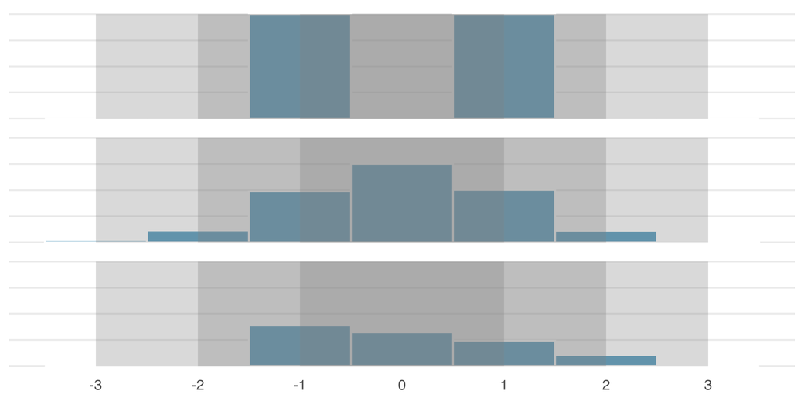

三個分布的平均數都是 0，標準差都是 1。哪一張圖的形狀最像你原先想像的？

中心和散布相同，仍可能有不同的偏態或峰數；摘要數字不能取代看圖。

IMS §5.4 · 官方線上版 Figure 5.7

## 移動一個極端值，哪些數字會變？

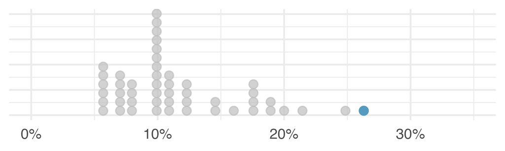

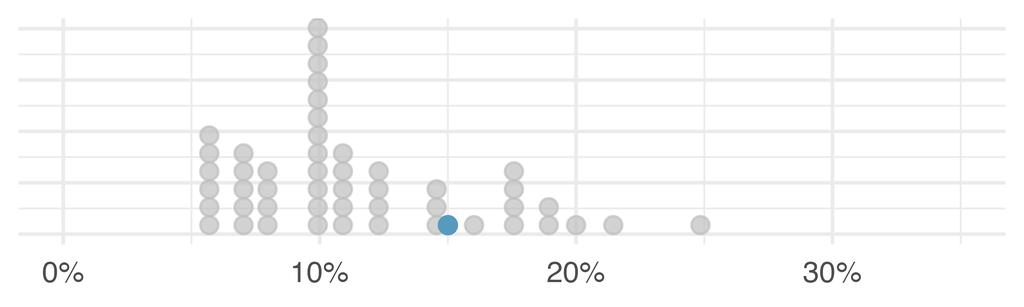

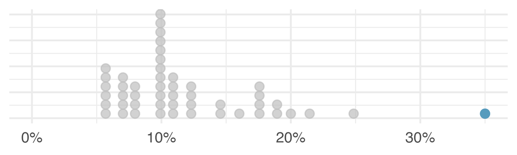

依序是原始值、移到 15%、移到 35%。中位數與 IQR 在三種情況都維持 **9.93%、5.75 個百分點**；平均數和標準差則跟著移動。

| 情況 | 平均數 | 標準差 |
| --- | --- | --- |
| 原始 | 11.6 | 5.05 |
| 移到 15% | 11.3 | 4.61 |
| 移到 35% | 11.7 | 5.68 |

IMS §5.6 Robust statistics · 官方線上版 Figure 5.9 · Table 5.4

## 練習：12 個差距，中位數落在平均數哪一邊？

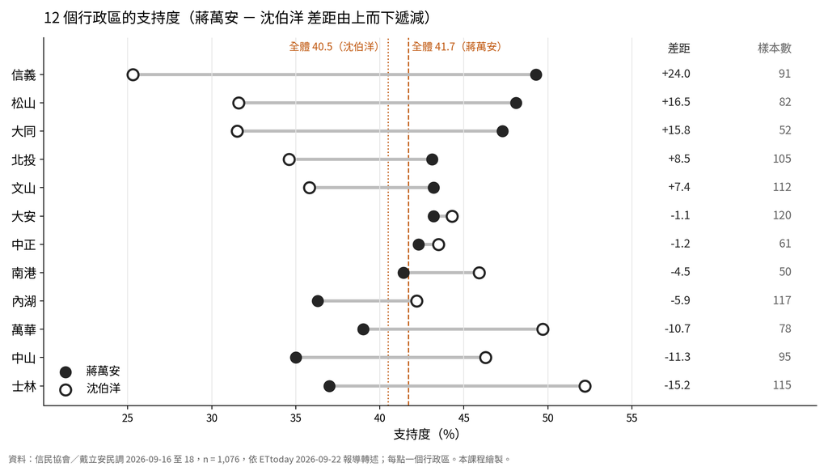

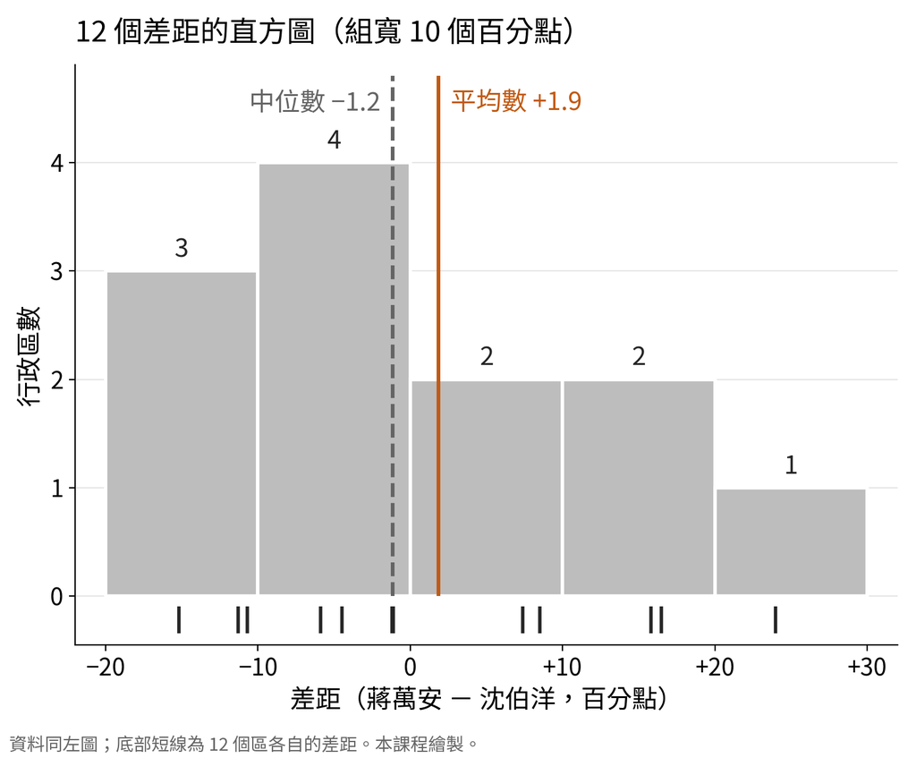

右圖把同樣 12 個差距畫成直方圖。中位數是 **−1.2**，平均數是 **+1.9**。長尾在哪一側？哪幾個區把平均往那一側拉？若只能報一個典型值，你會選哪一個？

**右偏**：信義 +24.0、松山 +16.5、大同 +15.8 形成右側長尾，把平均數往右拉；中位數較不受它們影響。12 個值就能看出偏態，但不足以談形狀的細節。

IMS §5.3、§5.6 概念應用 · 本課程自製圖；數字依報導轉述

## 練習：直方圖與盒形圖各看見什麼？

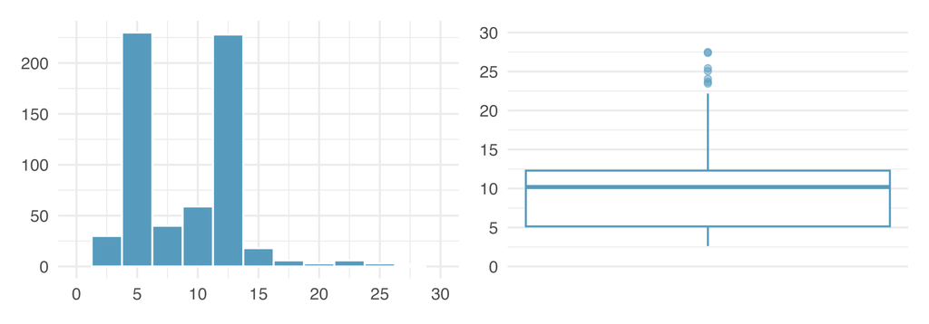

哪一種圖看得出峰的數目？哪一種圖直接標出四分位數？

直方圖保留形狀與峰數；盒形圖用少數位置快速顯示中心與散布。

IMS §5.10 Exercises · 題 13 Histograms vs. box plots

## 以類別分組比較數值

用「人口增加／未增加」分組，比較各郡的家庭收入中位數；每列仍是一個郡。

| 州 | 郡 | 人口變化（%） | 分組 | 家庭收入中位數 |
| --- | --- | --- | --- | --- |
| Arkansas | Izard County | 2.13 | 增加 | 39135 |
| Georgia | Jackson County | 10.17 | 增加 | 57999 |
| Oregon | Hood River County | 3.41 | 增加 | 57269 |
| Texas | Montague County | 0.75 | 增加 | 46592 |
| Kentucky | Ballard County | -2.62 | 未增加 | 42988 |
| Kentucky | Letcher County | -5.13 | 未增加 | 30293 |
| Texas | Jim Hogg County | -1.12 | 未增加 | 31403 |
| Virginia | Richmond County | -0.19 | 未增加 | 47341 |

這 8 個郡不足以描述兩群郡的收入分布；比較時還要看全部 3,139 個郡的資料。

4.6 Comparing numerical data across groups · IMS Table 4.6

## 直方圖與並排盒形圖

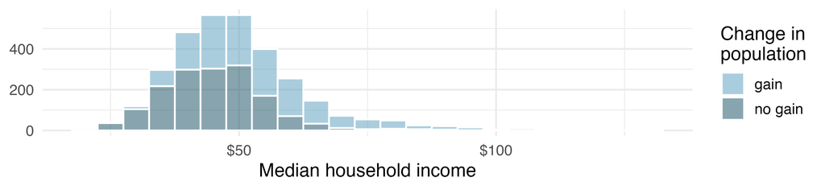

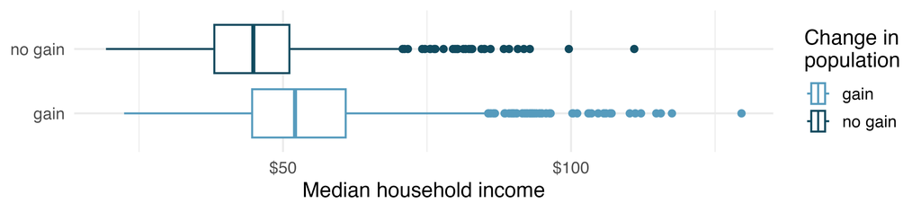

上為以顏色分組的直方圖（Figure 4.8a），下為並排盒形圖（4.8b）；同一份資料，3,139 個郡。兩組的中間位置差多少？形狀一樣嗎？

並排盒形圖（side-by-side box plot）壓縮成幾個摘要量；直方圖保留分布形狀

4.6 Comparing numerical data across groups · IMS Figure 4.8

## 脊線圖

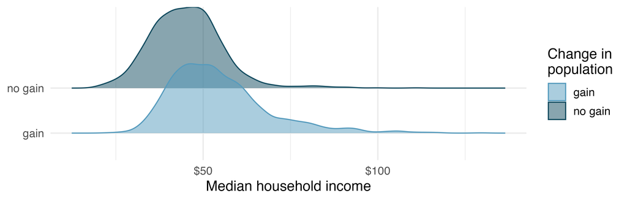

每一組的分布畫成一條曲線並上下排列。這張圖比盒形圖多告訴你什麼？比直方圖少了什麼？

脊線圖（ridge plot）：兼顧形狀與組間比較，但看不出各組的實際筆數

4.6 Comparing numerical data across groups · IMS Figure 4.9

## 分面：再加一個類別變項

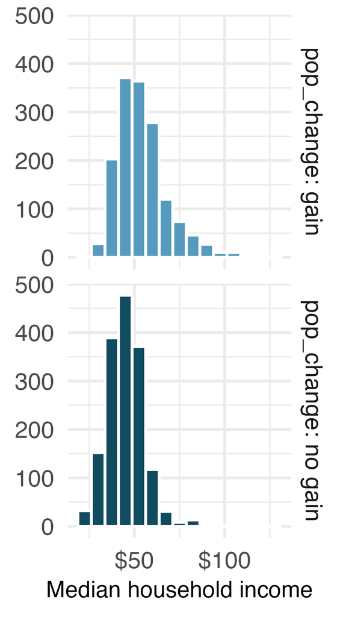

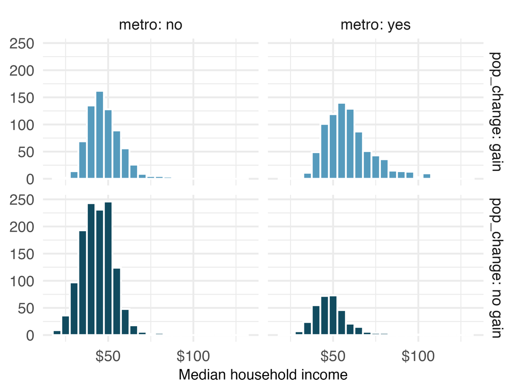

左：只依人口增減分成兩格（Figure 4.10a）。右：再加入是否位於都會區，分成四格（4.10b）。原本的差異在哪一格還在？哪一格變小了？

分面（faceting）：以類別變項切分成多個繪圖區，座標軸維持同一尺度

4.6 Comparing numerical data across groups · IMS Figure 4.10

## 一張圖能承載多少資訊？

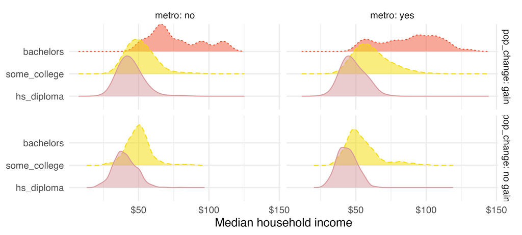

同時編碼四件事：收入分布、人口增減、是否位於都會區、教育程度中位數。讀懂這張圖需要幾個步驟？

4.6 Comparing numerical data across groups · IMS Figure 4.11

## 散布圖：一個點代表什麼？

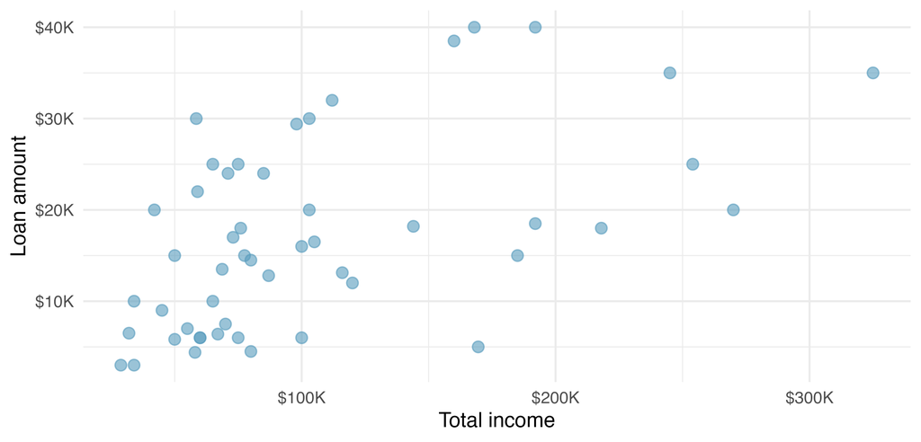

散布圖（scatterplot）把同一筆觀察的兩個數值放在橫軸與縱軸。這裡一點是一筆貸款。

IMS §5.1 Scatterplots for paired data · Figure 5.1

## 加一條模型線，看見整體趨勢

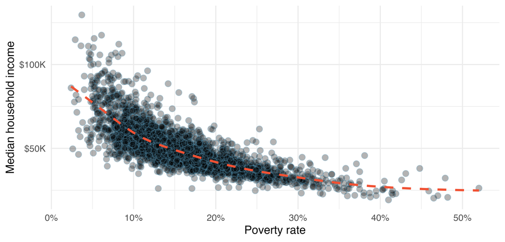

貧窮率較高的郡，中位數家庭收入通常較低。虛線呈現**非線性的負向關聯**；各郡仍會偏離這條線。

IMS §5.1 · Figure 5.2 · 2017 年 county 資料

## 對數轉換：同一份資料，換一種尺度

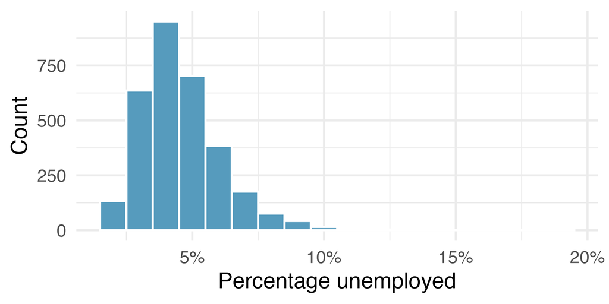

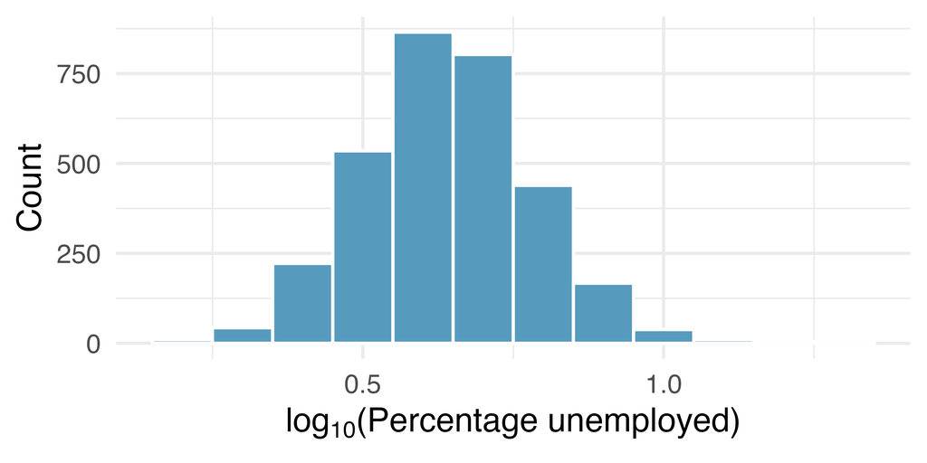

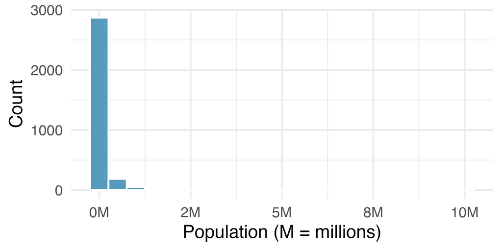

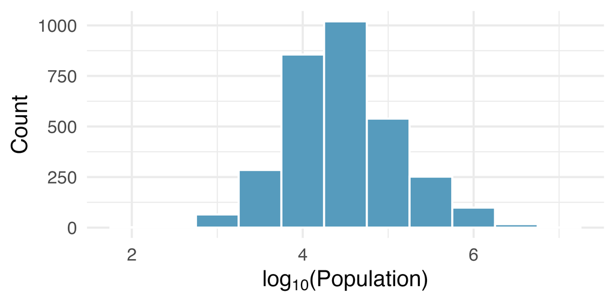

左上→右上：失業率原值與 log₁₀ 值；左下→右下：人口原值與 log₁₀ 值。橫軸改為對數尺度後，原本擠在一端的分布較易看清。對數轉換（log transformation）改變距離；直接取 log 需要正值。

IMS §5.7 Transforming data · 官方線上版 Figure 5.10a–d

## 對數轉換後，散布圖怎麼變？

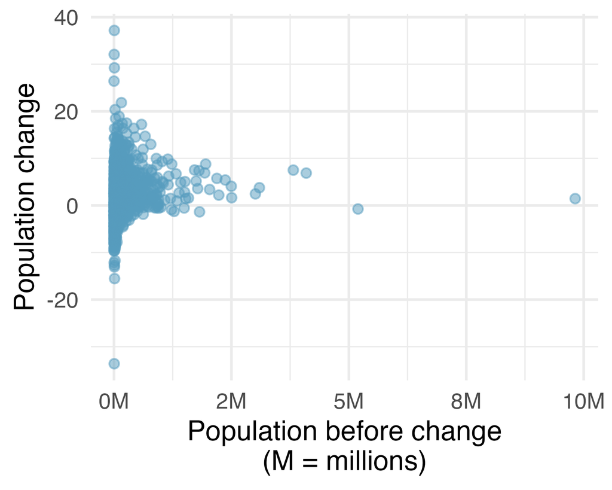

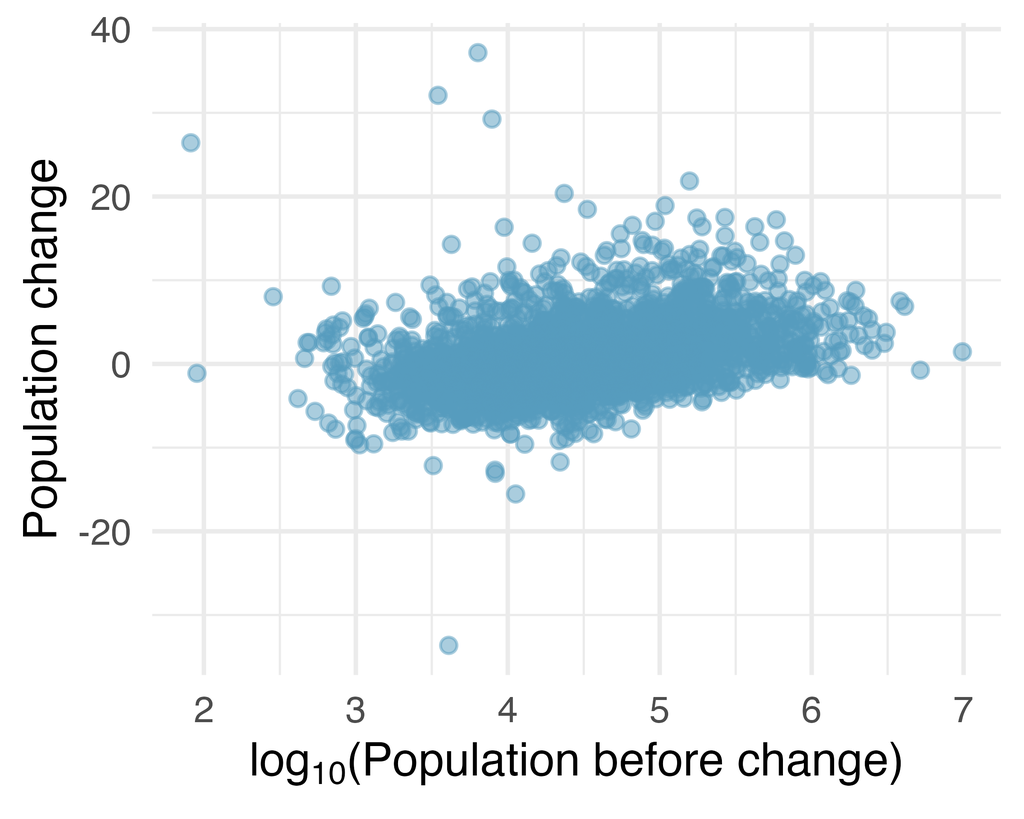

對數轉換也會改變散布圖中橫軸的距離。讀圖時要確認數字是否已經取 log₁₀；例如 log₁₀(100,000)＝5。

IMS §5.7 · 官方線上版 Figure 5.11a–b

## 加入第三個變項，方向可能反轉

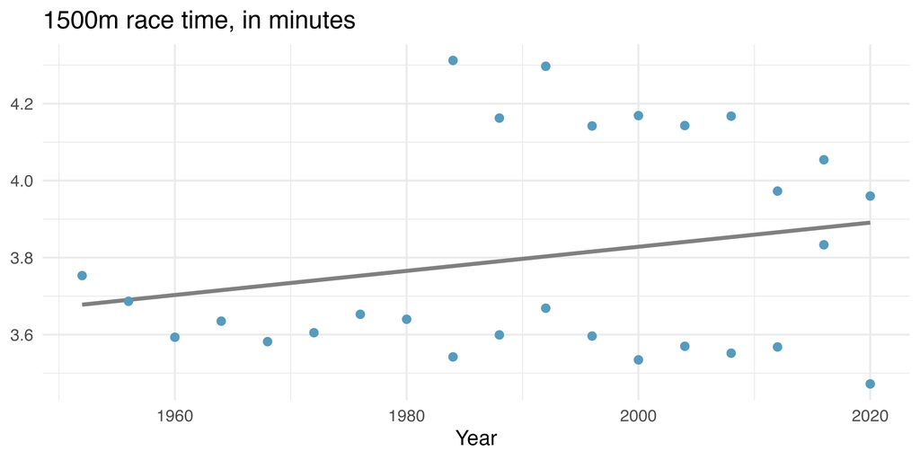

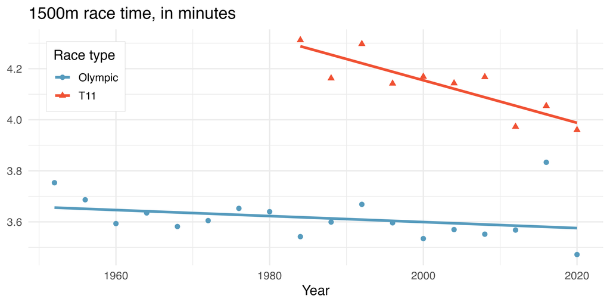

左圖合併看，線向上；右圖按賽事類型分開看，兩條線都向下。同一份資料，讀到的方向為什麼不同？

IMS §3.2 Simpson’s paradox · Figures 3.3–3.4

## 辛普森悖論：合併與分組的關係反轉

辛普森悖論（Simpson’s paradox）：兩個變項之間的關聯方向，在考慮第三個變項後反轉。

- 在 1500 公尺成績資料中，第三個變項是**賽事類型**。
- 兩種賽事的成績水準與出現年份分布不同；合併資料時，這種不平衡會改變整體趨勢。

描述這份資料時，分組趨勢比單一合併線更清楚；其他資料要依研究問題判斷如何報告。

IMS §3.2 Simpson’s paradox · Figures 3.3–3.4

## 開始分析前，先檢查資料品質

1. **遺漏值（missing value）：**有多少、集中在哪些人或變項、可能為何遺漏？民調的未表態 17.8% 與拒訪，都要先問「是誰沒答」。
2. **離群值：**是記錄錯誤、量測問題，還是真實的極端觀察？信義 +24.0 要先查它的樣本數，不是先刪。
3. **偏態：**平均數是否被長尾拉動？12 區差距的平均 +1.9 與中位數 −1.2 就不同。
4. **不平衡：**各組筆數差多少？南港 50 人與大安 120 人畫成標準化圖時一樣高，誤差卻差很多。

IMS §5.6、§3.2 · Rosner 8e §13.16（遺漏資料概念選讀）· 本課程整理；民調數字依報導轉述

## 練習：把結論改寫到資料能支持的範圍

待改寫：「最新民調顯示大同區藍贏綠、大安區綠贏藍，北市選情大翻轉。」

這句話用了哪些資料裡沒有的東西？觀察單位、樣本數、誤差、時間，各檢查一次。

參考改寫：「在 2026 年 9 月中的一項電話民調中（n ＝ 1,076），大同區 52 位受訪者中蔣萬安領先，大安區 120 位受訪者中沈伯洋領先 1.1 個百分點。區樣本很小，差距都在誤差範圍內；這是受訪者當時的表態，不是投票結果。」

同一種改寫也適用於教材的郡資料：「貧窮率越高**會造成**收入下降」要改成「在 2017 年美國各郡資料中，貧窮率較高的郡收入中位數通常較低；觀察資料，不能判定因果」。

IMS §5.1 概念應用 · 題句改編自 2026-09-22 報導標題，改寫為本課程自編

## 課後閱讀與來源

- *Introduction to Modern Statistics*, 2e：[Ch. 5 Exploring numerical data](https://openintrostat.github.io/ims/explore-numerical.html)，§5.1–5.7；[Ch. 4 Exploring categorical data](https://openintrostat.github.io/ims/explore-categorical.html)，§4.6；[Ch. 3 Applications: Data](https://openintrostat.github.io/ims/data-applications.html)，§3.2。
- 圖表來源：IMS Figures 5.1–5.11、4.8–4.11、3.3–3.4（線上版圖號）。讀圖練習取自 Ch. 5 題 6、13；偏態對照圖為本課程自製示意。
- 民調案例：12 個行政區的差距與樣本數依報導轉述；啞鈴圖為本課程自製。本課程未取得原始報告。
- 遺漏資料概念選讀：Rosner 8e §13.16。

IMS Ch. 5、Ch. 4 §4.6、Ch. 3 §3.2

## Part 1｜Slido 作答入口

[figure not shown]

掃描 QR code 進入 Slido，等待 **Part 1 Quiz** 開放。

無法掃描時，開啟 [Slido 作答入口](https://app.sli.do/event/9DzgBhTDhyRJFR5V1faviF)，或到 sli.do 輸入代碼 **2612995**。